# Sample Answer Lab01 : Data manipulation and `ggplot`

Yalin Yang

2020-03-10

# Task 1: Statistical Graphs (3 pts)

The following graphs are reproductions from the [R Graphics Cookbook, 2e](https://r-graphics.org/index.html). One of the objectives of task 1 is that you visit the **R Graphics Cookbook** and explore the graphs on display there.

Study the sections associated with the graphs which are displayed in task 1.1 to 1.6. Its sections document how these graphs were build. For *educational purposes* you may want to read the associated documentation of the employed functions and experiment with their options.

You job in task 1 is to reproduce these graphs and show the code, which generated them. The data used in the **R Graphics Cookbook** are available in `library("gcookbook")`.

## Task 1.1 (0.5 pts)

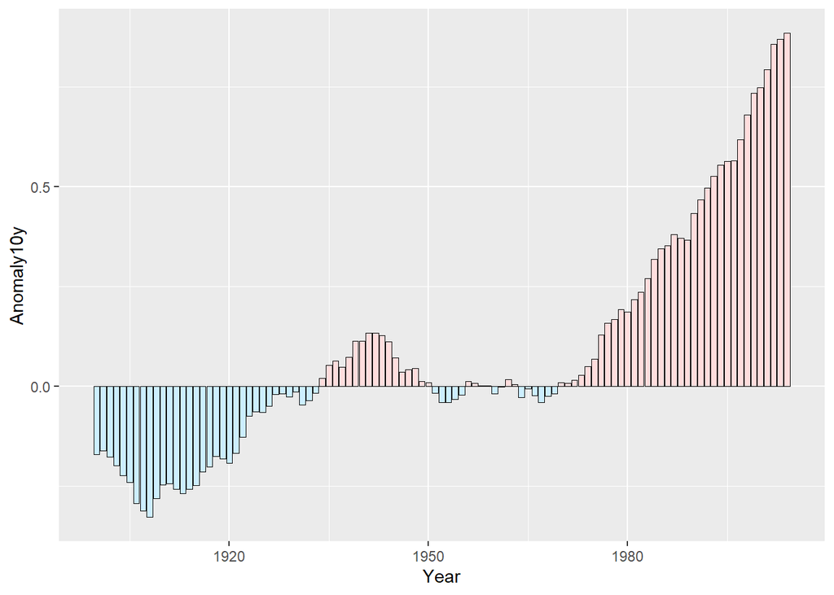

```r
climate_sub <- climate %>% filter(Source == "Berkeley" & Year >= 1900) %>%
  mutate(pos=Anomaly10y >= 0)

ggplot(climate_sub, aes(x=Year, y=Anomaly10y, fill=pos)) +
  geom_col(position="identity", colour="black", size=0.25) +
  scale_fill_manual(values = c("#CCEEFF","#FFDDDD"), guide=FALSE)
```

## Task 1.2 (0.5 pts)

```r
library(MASS)
```

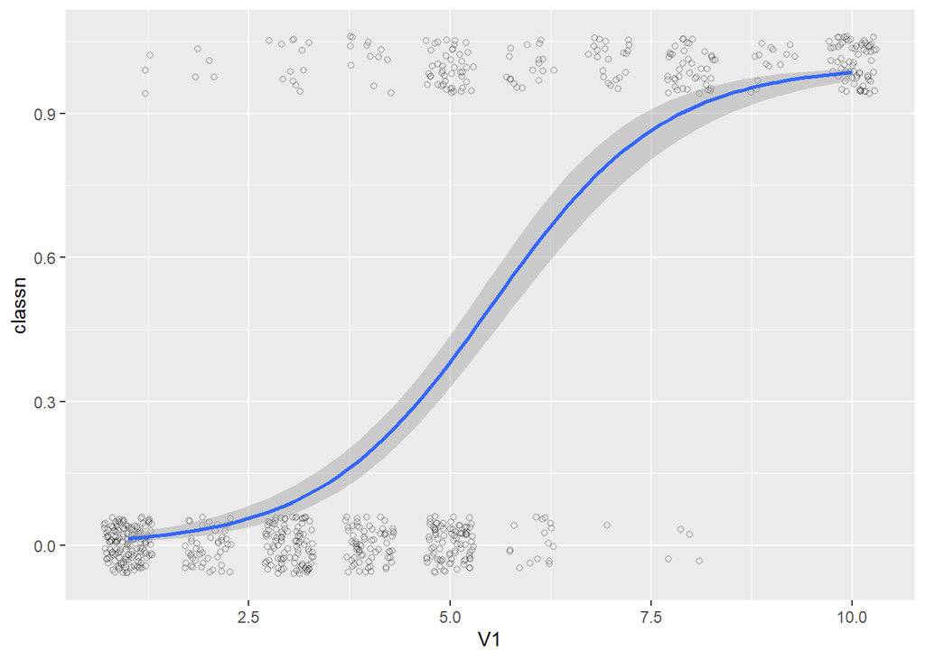

```r
biopsy_mod <- biopsy %>% mutate(classn = recode(class, benign=0, malignant=1))

ggplot(biopsy_mod, aes(x=V1, y=classn))+
  geom_point(position=position_jitter(width=0.3, height=0.06), alpha=0.4, shape=21, size=1.5)+
  stat_smooth(method=glm, method.args=list(family=binomial))
```

## Task 1.3 (0.5 pts)

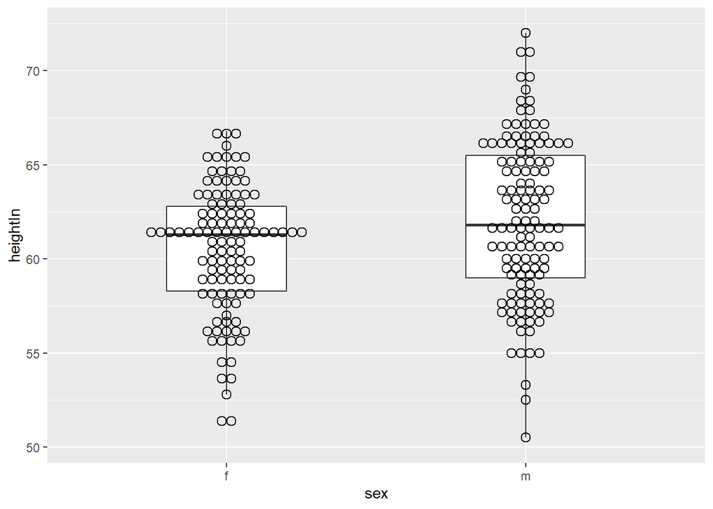

```r
ggplot(heightweight, aes(x=sex, y=heightIn)) +
  geom_boxplot(outlier.colour = NA, width= 0.4)+
  geom_dotplot(binaxis = "y", binwidth = 0.5, stackdir = "center", fill=NA)
```

## Task 1.4 (0.5 pts)

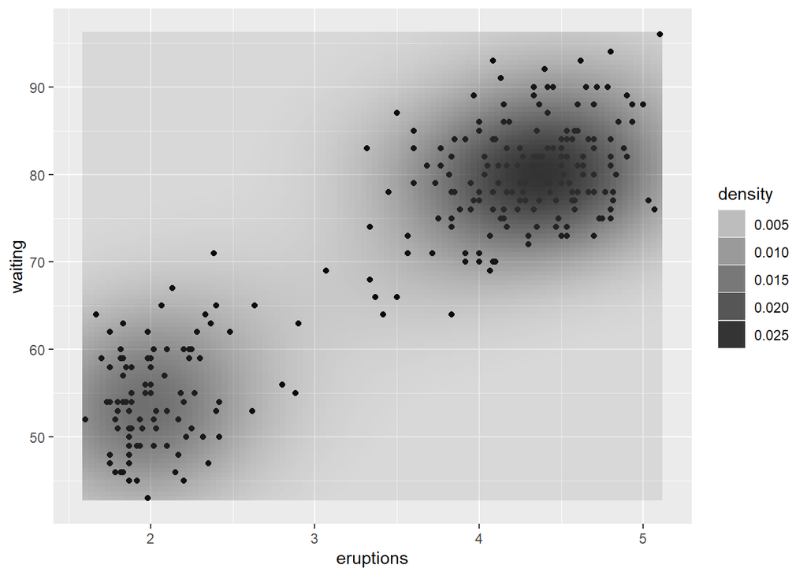

```r
ggplot(faithful, aes(x=eruptions, y=waiting))+
  geom_point()+
  stat_density2d(aes(alpha=..density..), geom="tile", contour = FALSE)
```

## Task 1.5 (0.5 pts)

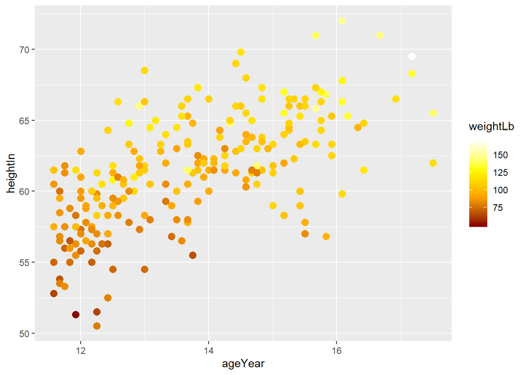

```r
library(scales)
ggplot(heightweight, aes(x=ageYear, y=heightIn, colour=weightLb))+
  geom_point(size=3)+
  scale_colour_gradientn(colours = c("darkred","orange","yellow","white"))
```

## Task 1.6 (0.5 pts)

For this map you would need to setup the data with

```r
library(maps)
library(mapproj)
states_map <- map_data("state")
crimes <- data.frame(state=tolower(rownames(USArrests)),USArrests)
crime_map <- merge(states_map, crimes, by.x="region", by.y="state")

qa <- quantile(crimes$Assault, seq(0,1,by=0.2))
crimes$Assault_q <- cut(crimes$Assault, qa, labels=c("0-20%","20-40%","40-60%","60-80%","80-100%"),
                       include.lowest = TRUE)
pal <- colorRampPalette(c("#559999","grey80","#BB650B"))(5)
ggplot(crimes, aes(map_id=state, fill=Assault_q))+
  geom_map(map=states_map, color="black")+
  scale_fill_manual(values=pal)+
  expand_limits(x=states_map$long, y=states_map$lat)+
  coord_map("polyconic")+
  labs(fill="Assault Rate\nPercentile")
```

[output not shown]

# Task 2: Grouped Data (1 pt)

Continue with the `flights` data in `library(nycflights13)`. Use the `str( )` and `View( )` functions to evaluated the data structure. To best understand how grouping of records works one needs to look at the resulting data structure.

## Task 2.1 (0.2 pts)

Describe the organization of the original `flights` data with respect to its variables and the nesting of the records according to `year`, `month` and `day`.

```r
library(nycflights13)
str(flights)
```

```
## Classes 'tbl_df', 'tbl' and 'data.frame':    336776 obs. of  19 variables:
##  $ year          : int  2013 2013 2013 2013 2013 2013 2013 2013 2013 2013 ...
##  $ month         : int  1 1 1 1 1 1 1 1 1 1 ...
##  $ day           : int  1 1 1 1 1 1 1 1 1 1 ...
##  $ dep_time      : int  517 533 542 544 554 554 555 557 557 558 ...
##  $ sched_dep_time: int  515 529 540 545 600 558 600 600 600 600 ...
##  $ dep_delay     : num  2 4 2 -1 -6 -4 -5 -3 -3 -2 ...
##  $ arr_time      : int  830 850 923 1004 812 740 913 709 838 753 ...
##  $ sched_arr_time: int  819 830 850 1022 837 728 854 723 846 745 ...
##  $ arr_delay     : num  11 20 33 -18 -25 12 19 -14 -8 8 ...
##  $ carrier       : chr  "UA" "UA" "AA" "B6" ...
##  $ flight        : int  1545 1714 1141 725 461 1696 507 5708 79 301 ...
##  $ tailnum       : chr  "N14228" "N24211" "N619AA" "N804JB" ...
##  $ origin        : chr  "EWR" "LGA" "JFK" "JFK" ...
##  $ dest          : chr  "IAH" "IAH" "MIA" "BQN" ...
##  $ air_time      : num  227 227 160 183 116 150 158 53 140 138 ...
##  $ distance      : num  1400 1416 1089 1576 762 ...
##  $ hour          : num  5 5 5 5 6 5 6 6 6 6 ...
##  $ minute        : num  15 29 40 45 0 58 0 0 0 0 ...
##  $ time_hour     : POSIXct, format: "2013-01-01 05:00:00" "2013-01-01 05:00:00" ...
```

**This statement shows a data-frame or tibble in its standard format: variables by cases.**

## Task 2.2 (0.5 pts)

Which **attributes** are added to the *tibble* `flights_ymd` once the data are grouped? Use the grouping code:

```r
flights_ymd <- flights %>% group_by(year, month, day)
str(flights_ymd)
```

How do subsequent function calls know which set of observations belongs to which group?

**The `group_by` function adds a list of attributes to the `tibble`, which lets subsequent function calls know how the data are grouped. For each group it provides a vector of record indices. Having grouped the data by month and day there are in total 365 groupings, one for each day with the index of all flights happing during each day.**

## Task 2.3 (0.2 pts)

Describe how the grouping structure of `flights_ym` changes after executing the code:

```r
flights_ym <- summarize(flights_ymd, flights=n())
str(flights_ym)
```

**It summarizes the grouped `tibble` based on lowest level group indices (i.e., days of each month), Therefore, records at the lowest level `aggregated` into the upper level of *month*. In this example all records are aggrated into the 12 months.**

## Task 2.4 (0.1 pts)

What does the `ungroup` function do to the data structure of `flights_new`. Evaluate the output of the code:

```r
flights_new <- flights_ymd  %>% ungroup()
```

**Transform a grouped table to an ordinary one by dropping groups attribute information.**

# Task 3: Sequential, Nested or Piped Execution of Commands (1 pt)

## Task 3.1 (0.6 pts)

Create a simple example using real data and function calls of a sequence of commands. Show for your example for the three different implementations:

- Sequential:

  ```
      y <- f(x)
      z <- g(y)
  ```

- Nested:

  ```
     z <- g(f(x))
  ```

- Piped:

  ```
     z <- x %>% f( ) %>% g( )
  ```

Each implementation should give identical results `z`.

```r
x <- 16
y <- sqrt(x)
z <- log(y)
z
```

```
## [1] 1.386294
```

```r
z <- log(sqrt(x))
z
```

```
## [1] 1.386294
```

```r
z <- x %>% sqrt( ) %>% log( )
z
```

```
## [1] 1.386294
```

## Task 3.2 (0.4 pts)

Discuss the practical advantages and disadvantages of each implementation.

**1.When you need the keep the value of the intermediate variable, could use the sequential approach**

**2.If intermediate variables are not, and two functions do not need many arguments, using nested command sequence could reduce blocking valuable computer memory. Nested command sequence is harder to read because it is interpreted from the inside to outside expressions.**

**3.The same situation as in the second scenario. However, piping is easier to read because it shows the operations explicitly in their order.**